# Group by & Summarize

## 1 Learning objectives

1. You can use `dplyr::summarize()` to extract summary statistics from datasets.
2. You can use `dplyr::group_by()` to group data by one or more variables before performing operations on them.
3. You understand why and how to **ungroup** grouped data frames.
4. You can use `dplyr::n()` together with `group_by()`-`summarize()` to count rows per group.
5. You can use `sum()` together with `group_by()`-`summarize()` to count rows that meet a condition.
6. You can use `dplyr::count()` as a handy function to count rows per group.

## 2 The Yaounde COVID-19 dataset

```r
yaounde <- read_csv(here::here('data/yaounde_data.csv'))

# A smaller subset of variables
yao <- yaounde %>%
  select(
  age, age_category_3, sex, weight_kg, height_cm,
  neighborhood, is_smoker, is_pregnant, occupation,
  treatment_combinations, symptoms, n_days_miss_work, n_bedridden_days,
  highest_education, igg_result)

yao
```

```
## # A tibble: 971 × 15
##      age age_category_3 sex    weight_kg height_cm neighborhood is_smoker
##    <dbl> <chr>          <chr>      <dbl>     <dbl> <chr>        <chr>
##  1    45 Adult          Female        95       169 Briqueterie  Non-smoker
##  2    55 Adult          Male          96       185 Briqueterie  Ex-smoker
##  3    23 Adult          Male          74       180 Briqueterie  Smoker
##  4    20 Adult          Female        70       164 Briqueterie  Non-smoker
##  5    55 Adult          Female        67       147 Briqueterie  Non-smoker
##  6    17 Child          Female        65       162 Briqueterie  Non-smoker
##  7    13 Child          Female        65       150 Briqueterie  Non-smoker
##  8    28 Adult          Male          62       173 Briqueterie  Non-smoker
##  9    30 Adult          Male          73       170 Briqueterie  Non-smoker
## 10    13 Child          Female        56       153 Briqueterie  Non-smoker
## # ℹ 961 more rows
## # ℹ 8 more variables: is_pregnant <chr>, occupation <chr>,
## #   treatment_combinations <chr>, symptoms <chr>, n_days_miss_work <dbl>,
## #   n_bedridden_days <dbl>, highest_education <chr>, igg_result <chr>
```

## 3 What are summary statistics?

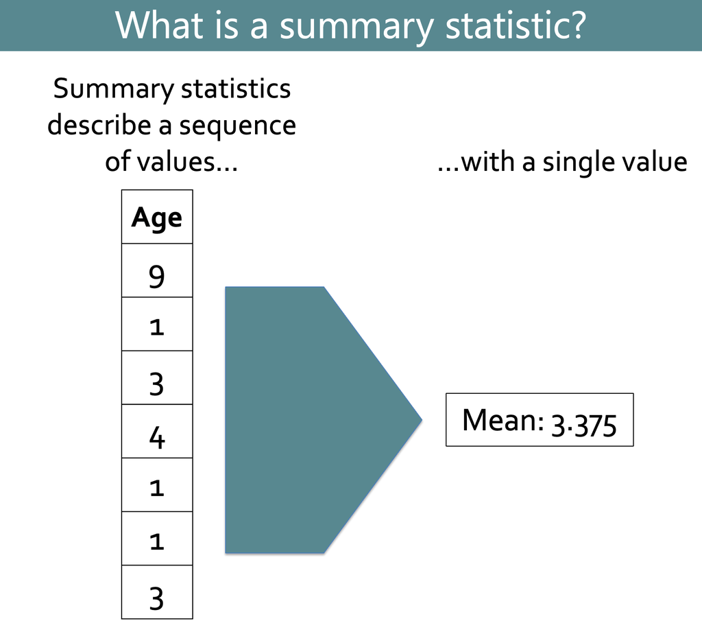

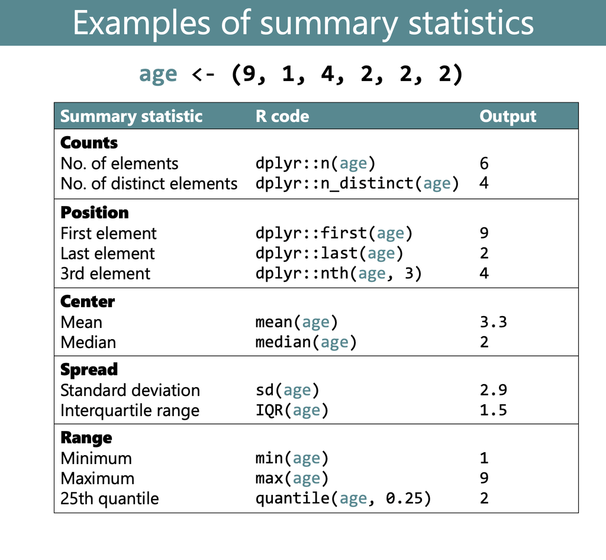

- **Why does it matter?**
- A common operation in most data analysis workflows
- You need to become fluent in computing them
- There is no better tool than the {dplyr} function `summarize()`!

## 4 Introducing `dplyr::summarize()`

- To start, let’s compute summary statistics *without* using `summarize()`
- Then we will see **why you *should* use it**.
- Let’s see how you would find the mean age of respondents in the `yao` data frame.

```r
# $ allows you to extract a data frame column to a vector
# then let's look at the first 10 items of the vector
yao_age <- yao$age
head(yao_age, 10)
```

```
##  [1] 45 55 23 20 55 17 13 28 30 13
```

```r
# let's pass this yao$age vector into mean()
mean(yao$age)
```

```
## [1] 29.01751
```

And that’s it! Extremely easy, right?

- Now let’s see *how* to obtain summary statistics with `summarize()`
- Going back to the the previous example:

```r
yao %>%
  # let's use summarize to get the mean age
 summarize(mean_age = mean(age))
```

```
## # A tibble: 1 × 1
##   mean_age
##      <dbl>
## 1     29.0
```

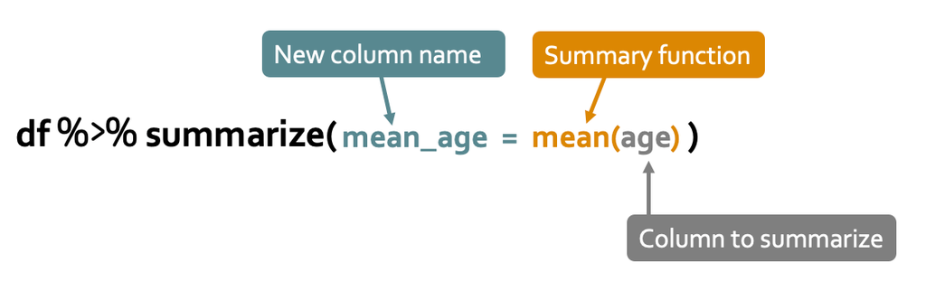

*Fig.* Basic syntax for the `summarize()` function.

- You can also compute **multiple summary statistics**

```r
yao %>%
  # let's calculate the mean and the median age at the same time !
  summarize( age_mean = mean(age),
             age_median = median(age))
```

```
## # A tibble: 1 × 2
##   age_mean age_median
##      <dbl>      <dbl>
## 1     29.0         26
```

Nice and simple!

- The resulting `summarize()` **data frame** has **each statistic** in **its respective column**.
- The main **benefit** is for producing *grouped* **summaries:** coming in the next section !

PRACTICE TIME !

Use `summarize()` and the relevant summary functions to obtain the mean, median and standard deviation of respondent weights from the `weight_kg` variable of the `yao` data frame.

Your output should be a data frame with three columns named as shown below:

| mean_weight_kg | median_weight_kg | sd_weight_kg |
| --- | --- | --- |

```r
Q_weight_summary <-
  yao %>%
  summarize(mean_weight_kg = mean(weight_kg),
            median_weight_kg = median(weight_kg),
            sd_weight_kg = sd(weight_kg))

Q_weight_summary
```

```
## # A tibble: 1 × 3
##   mean_weight_kg median_weight_kg sd_weight_kg
##            <dbl>            <dbl>        <dbl>
## 1           64.4               66         23.1
```

Use `summarize()` and the relevant summary functions to obtain the minimum and maximum respondent heights from the `height_cm` variable of the `yao` data frame.

Your output should be a data frame with two columns named as shown below:

| min_height_cm | max_height_cm |
| --- | --- |

```r
Q_height_summary <-
  yao %>%
  summarize(
    min_height_cm = min(height_cm),
    max_height_cm = max(height_cm)
            )
Q_height_summary
```

```
## # A tibble: 1 × 2
##   min_height_cm max_height_cm
##           <dbl>         <dbl>
## 1            54           196
```

```r
.CHECK_Q_height_summary()
.HINT_Q_height_summary()
```

## 5 Grouped summaries with `dplyr::group_by()`

- `dplyr::group_by()` lets you **group values together within a variable.**
- An intuitive grouping **example**: male vs female.
- **Operations** are then **split** (i.e. performed in parallel) according to each of the groups.

```r
yao %>%
  # let's group by sex
 group_by(sex)
```

```
## # A tibble: 971 × 15
## # Groups:   sex [2]
##      age age_category_3 sex    weight_kg height_cm neighborhood is_smoker
##    <dbl> <chr>          <chr>      <dbl>     <dbl> <chr>        <chr>
##  1    45 Adult          Female        95       169 Briqueterie  Non-smoker
##  2    55 Adult          Male          96       185 Briqueterie  Ex-smoker
##  3    23 Adult          Male          74       180 Briqueterie  Smoker
##  4    20 Adult          Female        70       164 Briqueterie  Non-smoker
##  5    55 Adult          Female        67       147 Briqueterie  Non-smoker
##  6    17 Child          Female        65       162 Briqueterie  Non-smoker
##  7    13 Child          Female        65       150 Briqueterie  Non-smoker
##  8    28 Adult          Male          62       173 Briqueterie  Non-smoker
##  9    30 Adult          Male          73       170 Briqueterie  Non-smoker
## 10    13 Child          Female        56       153 Briqueterie  Non-smoker
## # ℹ 961 more rows
## # ℹ 8 more variables: is_pregnant <chr>, occupation <chr>,
## #   treatment_combinations <chr>, symptoms <chr>, n_days_miss_work <dbl>,
## #   n_bedridden_days <dbl>, highest_education <chr>, igg_result <chr>
```

Let’s look at the header !

[output not shown]

Let’s combine `group_by()` and `summarize()` !

```r
yao %>%
  # we group by sex
  group_by(sex) %>%
  # we summarize to get the mean and median
  summarize( mean_age = mean(age),
             median_age = median(age))
```

```
## # A tibble: 2 × 3
##   sex    mean_age median_age
##   <chr>     <dbl>      <dbl>
## 1 Female     29.5         26
## 2 Male       28.4         25
```

This kind of grouped summary is the primary reason the `summarize()` is so useful!

- Let’s see another example:

```r
yao %>%
  # group by neighborhoods
  group_by(neighborhood) %>%
  # calculate the min and max weight
  summarize( min_weight = min(weight_kg),
             max_weight = max(weight_kg)
            )
```

```
## # A tibble: 9 × 3
##   neighborhood min_weight max_weight
##   <chr>             <dbl>      <dbl>
## 1 Briqueterie          20        128
## 2 Carriere             14        129
## 3 Cité Verte           16        118
## 4 Ekoudou              15        135
## 5 Messa                19         96
## 6 Mokolo               16        162
## 7 Nkomkana             15        161
## 8 Tsinga               15        105
## 9 Tsinga Oliga         17        100
```

Great! With just a few code lines you are able to extract quite a bit of information.

- Let’s see one more example for good measure.
- The variable `n_days_miss_work` tells us the number of days that respondents missed work due to COVID-like symptoms.

```r
yao %>%
  # let's keep only n_days_miss_work
  select(id,n_days_miss_work)
```

[output not shown]

```r
yao %>%
  # let's group by sex
  group_by(sex) %>%
  # let's sum the number of work days missed
  summarise(total_days_missed = mean(n_days_miss_work, na.rm = TRUE))
```

```
## # A tibble: 2 × 2
##   sex    total_days_missed
##   <chr>              <dbl>
## 1 Female              1.50
## 2 Male                2.18
```

- `summarize()` is so **powerful**.
- This practice is **very hands-on** and similar to what you will need in the field !

PRACTICE TIME !

Use `group_by()` and `summarize()` to obtain the mean weight (kg) by smoking status in the `yao` data frame. Name the average weight column `weight_mean`

The output data frame should look like this:

| is_smoker | weight_mean |
| --- | --- |
| Ex-smoker |  |
| Non-smoker |  |
| Smoker |  |
| NA |  |

```r
Q_weight_by_smoking_status <-
  yao %>%
  group_by(is_smoker) %>%
  summarize(weight_mean = mean(weight_kg))
Q_weight_by_smoking_status
```

[output not shown]

Use `group_by()`, `summarize()`, and the relevant summary functions to obtain the minimum and maximum heights for each sex in the `yao` data frame.

Your output should be a data frame with three columns named as shown below:

| sex | min_height_cm | max_height_cm |
| --- | --- | --- |
| Female |  |  |
| Male |  |  |

```r
Q_min_max_height_by_sex <-
  yao %>%
  group_by(sex) %>%
  summarize(min_height_cm = min(height_cm, na.rm = TRUE),
            max_height_cm = max(height_cm, na.rm = TRUE))

Q_min_max_height_by_sex
```

[output not shown]

```r
.CHECK_Q_min_max_height_by_sex()
```

[output not shown]

```r
.HINT_Q_min_max_height_by_sex()
```

```
##
## HINT.
## Your answer should look this:
##
## Q_min_max_height_by_sex <-
##   yao %>%
##   group_by(VARIABLE) %>%
##   summarize(min_height_cm = FORMULA_HERE,
##             max_height_cm = FORMULA_HERE)
```

Use `group_by()`, `summarize()`, and the `sum()` function to calculate the total number of bedridden days (from the `n_bedridden_days` variable) reported by respondents of each sex.

Your output should be a data frame with two columns named as shown below:

| sex | total_bedridden_days |
| --- | --- |
| Female |  |
| Male |  |

```r
Q_sum_bedridden_days <-
  yao %>%
  group_by(sex) %>%
  summarize(total_bedridden_days = sum(n_bedridden_days, na.rm = TRUE))
Q_sum_bedridden_days
```

```
## # A tibble: 2 × 2
##   sex    total_bedridden_days
##   <chr>                 <dbl>
## 1 Female                  175
## 2 Male                    163
```